# assignment_week_4

Noam Ghenassia

2022-10-21

## R Markdown

In this week’s assignment, the aim was to compare the effects of varying the bandwidth and kernel of the kernel density estimator. We generated a bimodal mixture distribution, and drew 200 sets of 100 observations from it. We then proceeded to estimate the density function using 9 different bandwidths and 3 kernels (the epanechnikov, gaussian and rectangular kernels).

Since the original distribution was known, we could compare it with the obtained estimations (using the 2-norm, i.e., $e = \lVert \hat{f} - f \rVert_2$). the following plot shows the aggregated results : the results are grouped by bandwidth :

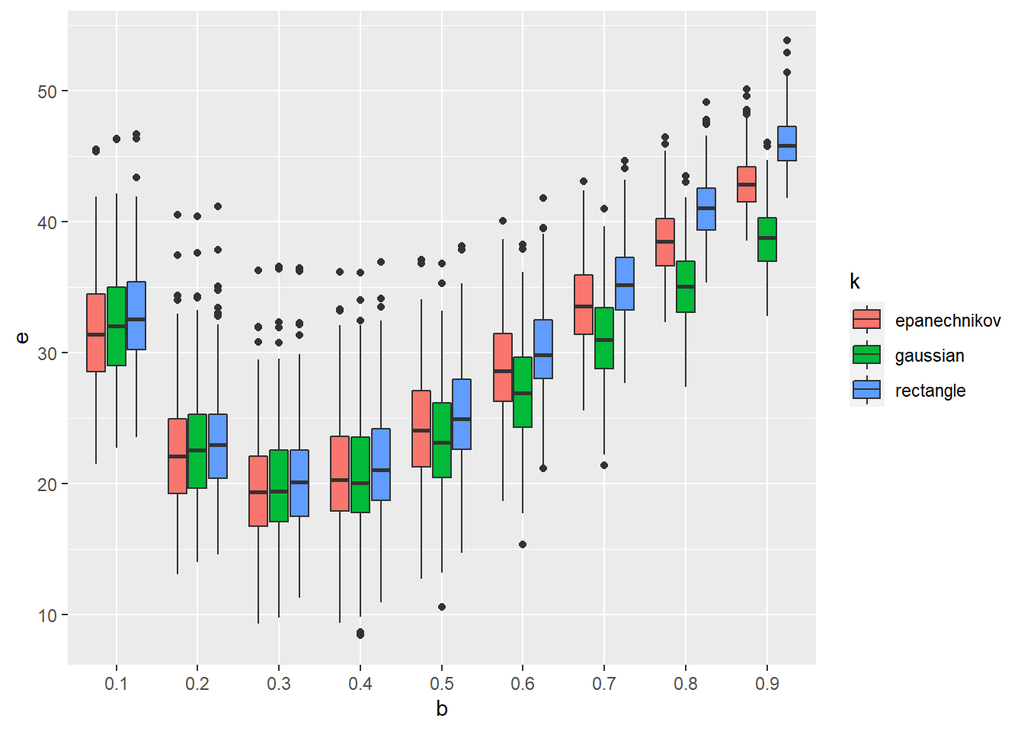

We can observe that similar bandwidths yield similar errors, while in general using different kernels does not have a dramatic effect on the error. The optimal bandwidth for this distribution with 100 observations appears to be somewhere between 0.3 and 0.4.

Finally, we can observe that as the bandwidth gets larger, the errors become more concentrated around different values for each kernel. On the other hand, smaller bandwidths yield a larger variance among the errors for all three kernels, but the average errors for the different kernels are relatively simmilar. This can be understood as a manifestation of the bias-variance tradeoff : for a large bandwidth, the variability among the drawn datasets has a smaller effect, while different kernel functions may have more importance. On the other hand, smaller badwidths have the opposite effect : the variability among the data sets have a bigger effect, but the average errors are more similar. The higher errors obtained with the smallest bandwidths might be due to some kind of “overfitting” of the dataset.